# RNA-analysis_GSE5281

DG

2026-04-16

## #The code below demostrates analysis of microarray expression intensities from the GSE5281 dataset

## 1. Install Packages and Load libraries

install.packages(“BiocManager”)

BiocManager::install(c(“GEOquery”, “limma”, “annotate”, “hgu133plus2.db”))

install.packages(“pheatmap”)

install.packages(c(“ggplot2”, “dplyr”, “ggrepel”))

install.packages(“UpSetR”)

install.packages(“matrixStats”)

library(GEOquery)

library(limma)

library(hgu133plus2.db)

library(pheatmap)

library(AnnotationDbi)

library(ggplot2)

library(dplyr)

library(ggrepel) # Optional but recommended for clean labeling

library(UpSetR)

library(matrixStats)

## 2. Load Data

gse <- getGEO(“GSE5281”, GSEMatrix = TRUE)

gse <- gse[[1]] #if multiple platforms select the first

expr <- exprs(gse) #expression matrix

meta <- pData(gse) #metadata

dim(expr) #check dimensions expression matrix

head(meta) #check expression metadata

## 3. Data Preprocessing

### 3.1. Ensure Consistent Labeling

colnames(meta) #look at metadata columns

lapply(meta[, grep(“characteristics”, colnames(meta))], unique) #check all the characteristics_c1.* columns to find the one with the group information details

meta$clean <- gsub("bio-source name:\\s*", "", meta$characteristics_ch1.1, ignore.case = TRUE) #case insensitive removal of “bio-source name:”

meta$clean <- tolower(meta$clean) #turn every letter to lowercase

meta$clean <- gsub(" ", "_", meta$clean) #replace spaces with underscores

meta$clean <- gsub("_+", "_", meta$clean) #fix messy underscores

unique(meta$clean) #check that the conversion was applied correctly

### 3.2. Rename variable labels to represent experimental factors

meta$group <- ifelse(grepl("affected", meta$clean), “AD”, “Control”) #disease variable classification

meta$region <- sub("^([a-z]+)_.*", "\\1", meta$clean) #brain region variable string extraction

meta$region <- toupper(meta$region) #make brain region abbreviations uppercase to comply with neuroscience labeling convention

unique(meta$region)

table(meta$region, useNA =“ifany”) #check for any unexpected values

table(meta$group, meta$region) #check correct conversion with group and region table

prop.table(table(meta$group, meta$region), margin = 2) #check for biological balance,QC

barplot(table(meta$group, meta$region), beside = TRUE, legend = TRUE) # check for biological balance,visualQC

### 3.3. Investigate raw data values - ranges show if the original data are log transformed

range(expr)

summary(as.vector(expr))

hist(expr, breaks = 100) #histogram

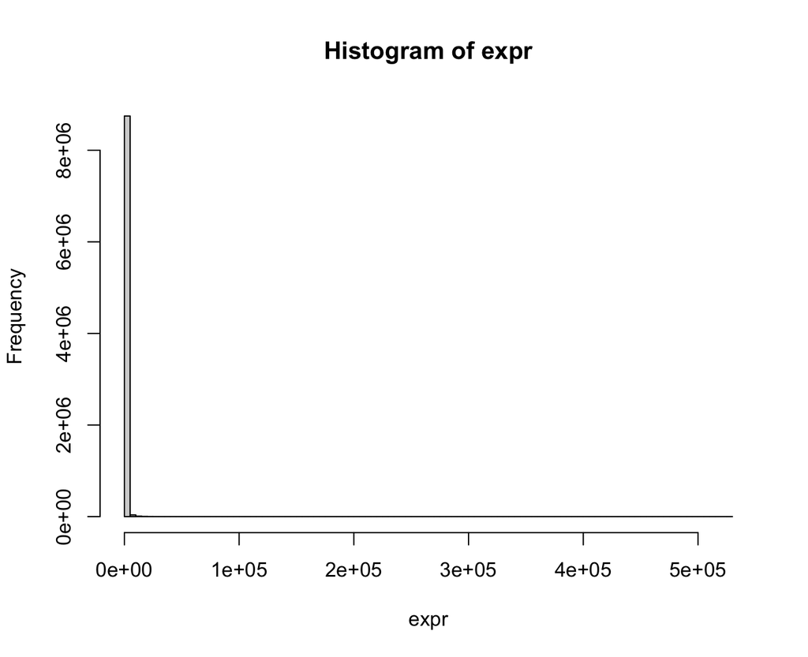

### 3.4. Perform log2 transformation

expr_log <- log2(expr + 1)

range(expr_log)

hist(expr_log, breaks = 100) #histogram

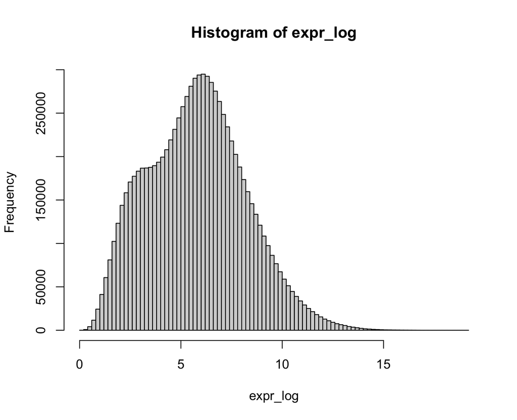

meta_clean <- data.frame( sample_id = colnames(expr), group = meta$group, region = meta$region, label = meta$clean )

all(meta_clean$sample_id == colnames(expr_log)) #check that the order matches the matrix

write.csv(meta_clean, “data/clean/meta_clean.csv”, row.names = FALSE) #save metadata

write.csv(expr_log, “data/clean/expr_log2.csv”) #save clean expression matrix

### 3.5. Perform Data Cleaning

expr_log_no_control <- expr_log[!grepl(“^AFFX”, rownames(expr_log)), ] #remove control (AFFX) probes

sum(grepl(“^AFFX”, rownames(expr_log_no_control))) #check it worked, should be 0

write.csv(expr_log_no_control, “data/clean/expr_log2_noAFFXcontrol.csv”) #save as .csv

expr_highconf <- expr_log_no_control[ !grepl(“_x_at$|_f_at$“, rownames(expr_log_no_control)),] #remove low specificity probes, keep only the high confidence ones

sum(grepl(“_x_at$|_f_at$“, rownames(expr_highconf))) #check it worked, should be 0

write.csv(expr_highconf, “data/clean/expr_log2_noAFFX_noX_noF.csv”) #save as .csv

### 3.6. Dataset Validation before limma analysis

dim(expr_highconf)

dim(meta_clean) #check dataset dimensions

all(colnames(expr_highconf) == meta_clean$sample_id) #check sample alignment

sum(is.na(expr_highconf)) #check for missing values

### 3.7. Check expression distribution

hist(expr_highconf, breaks = 100) #histogram

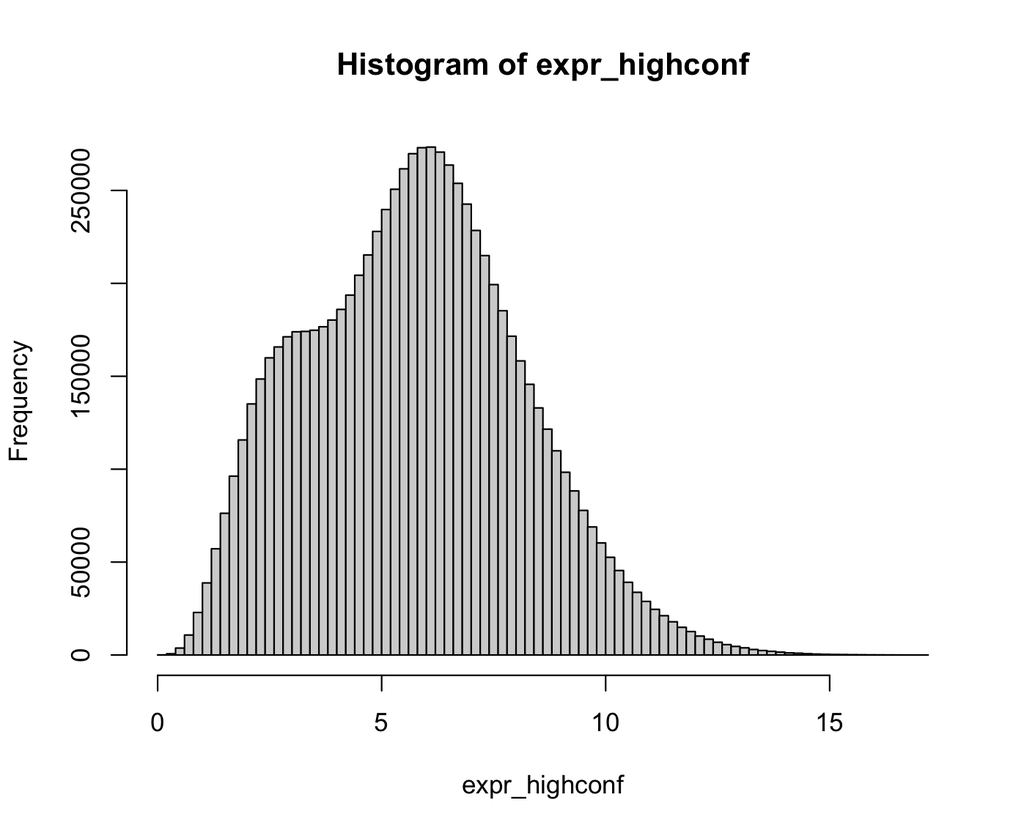

plot(rowMeans(expr_highconf), matrixStats::rowVars(as.matrix(expr_highconf)), xlab = “Mean”, ylab = “Variance”) #mean variance

table(meta_clean$group, meta_clean$region) #check group balance

meta_clean$group_region <- factor( paste(meta_clean$group, meta_clean$region, sep = “_“) )

design <- model.matrix(~ 0 + group_region, data = meta_clean)

colnames(design) <- levels(meta_clean$group_region)

qr(design)$rank == ncol(design)

table(meta_clean$group_region) #check proper matrix formation

[figure not shown]

### 4. Limma Analysis

### 4.1. Load Data

load(“data/clean/expr_log2_noAFFX_noX_noF.csv”) #load cleaned data

### 4.2. Align metadata

meta <- meta[match(colnames(expr_highconf), rownames(meta)), ]

### 4.3. Create group_region

meta$group_region <- factor(paste(meta$group, meta$region, sep = “_“))

design <- model.matrix(~ 0 + group_region, data = meta)

colnames(design) <- levels(meta$group_region)

### 4.4. Define contrasts

contrasts <- makeContrasts( EC = AD_EC - Control_EC, HIP = AD_HIP - Control_HIP, MTG = AD_MTG - Control_MTG, PC = AD_PC - Control_PC, SFG = AD_SFG - Control_SFG, VCX = AD_VCX - Control_VCX, levels = design ) #define contrasts

contrasts #check contrast matrix

### 4.5. Fit the model

fit <- lmFit(expr_highconf, design)

fit2 <- contrasts.fit(fit, contrasts)

fit2 <- eBayes(fit2) #fit limma model with contrasts

### 4.6. Extract results

res_EC <- topTable(fit2, coef = “EC”, number = Inf) #extract results per brain region

results_list <- lapply(colnames(contrasts), function(region) { topTable(fit2, coef = region, number = Inf) }) #loop for all regions

names(results_list) <- colnames(contrasts)

### 4.7. Save results

for (region in names(results_list)) { write.csv( results_list[[region]], paste0(“results/limma_”, region, “.csv”), row.names = TRUE ) } #save results for all regions

results_list

results_list[[“EC”]] #results list for each element

### 4.8. Annotate results

annotate_results <- function(res_table) {

probe_ids <- rownames(res_table)

res_table$SYMBOL <- mapIds( hgu133plus2.db, keys = probe_ids, column = “SYMBOL”, keytype = “PROBEID”, multiVals = “first” )

res_table$ENTREZID <- mapIds( hgu133plus2.db, keys = probe_ids, column = “ENTREZID”, keytype = “PROBEID”, multiVals = “first” )

res_table$GENENAME <- mapIds( hgu133plus2.db, keys = probe_ids, column = “GENENAME”, keytype = “PROBEID”, multiVals = “first” )

return(res_table) } #annotate results

annotated_results <- lapply(results_list, annotate_results) #apply annotation to all regions

dir.create(“results/annotated”, showWarnings = FALSE)

for (region in names(annotated_results)) {

file_name <- paste0(“results/annotated/limma_”, region, “_annotated.csv”)

write.csv( annotated_results[[region]], file = file_name, row.names = TRUE ) } #save the annotated results per region

all_probes <- rownames(expr_highconf)

### 4.9. Generate standalone mapping file

probe_map <- data.frame( PROBEID = all_probes, SYMBOL = mapIds(hgu133plus2.db, all_probes, “SYMBOL”, “PROBEID”, multiVals = “first”), ENTREZID = mapIds(hgu133plus2.db, all_probes, “ENTREZID”, “PROBEID”, multiVals = “first”), GENENAME = mapIds(hgu133plus2.db, all_probes, “GENENAME”, “PROBEID”, multiVals = “first”) ) #create a standalone mapping file

write.csv(probe_map, “data/clean/probe_to_gene_mapping.csv”, row.names = FALSE) #save the file

### 4.10. Filter significant genes

sig_EC <- annotated_results[[“EC”]]

sig_EC <- sig_EC[sig_EC$adj.P.Val < 0.05, ] #filter significant genes

dir.create(“results/DE/filtered_significant”, recursive = TRUE, showWarnings = FALSE)

dir.create(“results/plots/volcano”, recursive = TRUE, showWarnings = FALSE)

dir.create(“results/plots/cross_region”, recursive = TRUE, showWarnings = FALSE)

dir.create(“results/summaries/top_genes”, recursive = TRUE, showWarnings = FALSE) #create directories to store analyses

padj_cutoff <- 0.05 #save significant genes per region

save_significant <- function(df, region_name) {

sig <- df[df$adj.P.Val < padj_cutoff, ]

# order by significance sig <- sig[order(sig$adj.P.Val), ]

write.csv( sig, file = paste0(“results/DE/filtered_significant/sig_”, region_name, “.csv”), row.names = TRUE )

return(sig) } #function to filter significnt genes

sig_list <- lapply(names(annotated_results), function(r) { save_significant(annotated_results[[r]], r) })

names(sig_list) <- names(annotated_results) #apply to all regions

### 5. Visualisations

### 5.1. Draw Volcano Plots

plot_volcano <- function(df, region_name) {

df$negLogP <- -log10(df$adj.P.Val)

df$label <- ifelse(df$adj.P.Val < 0.05 & abs(df$logFC) > 1, df$SYMBOL, NA)

p <- ggplot(df, aes(x = logFC, y = negLogP)) + geom_point(alpha = 0.5) + geom_text(aes(label = label), na.rm = TRUE, size = 3) + ggtitle(paste(“Volcano Plot -”, region_name)) + xlab(“log2 Fold Change”) + ylab(“-log10 adj P-value”)

ggsave( filename = paste0(“results/plots/volcano/volcano_”, region_name, “.png”), plot = p, width = 6, height = 5 ) }

lapply(names(annotated_results), function(r) { plot_volcano(annotated_results[[r]], r) })

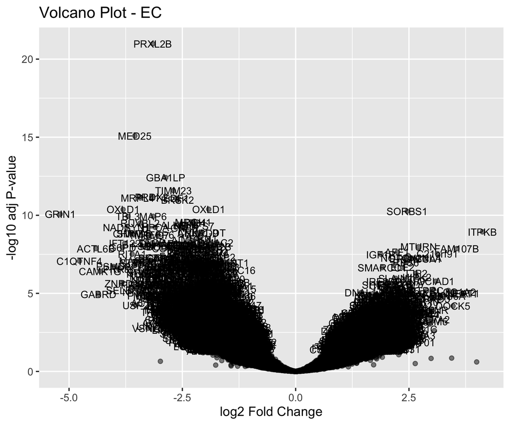

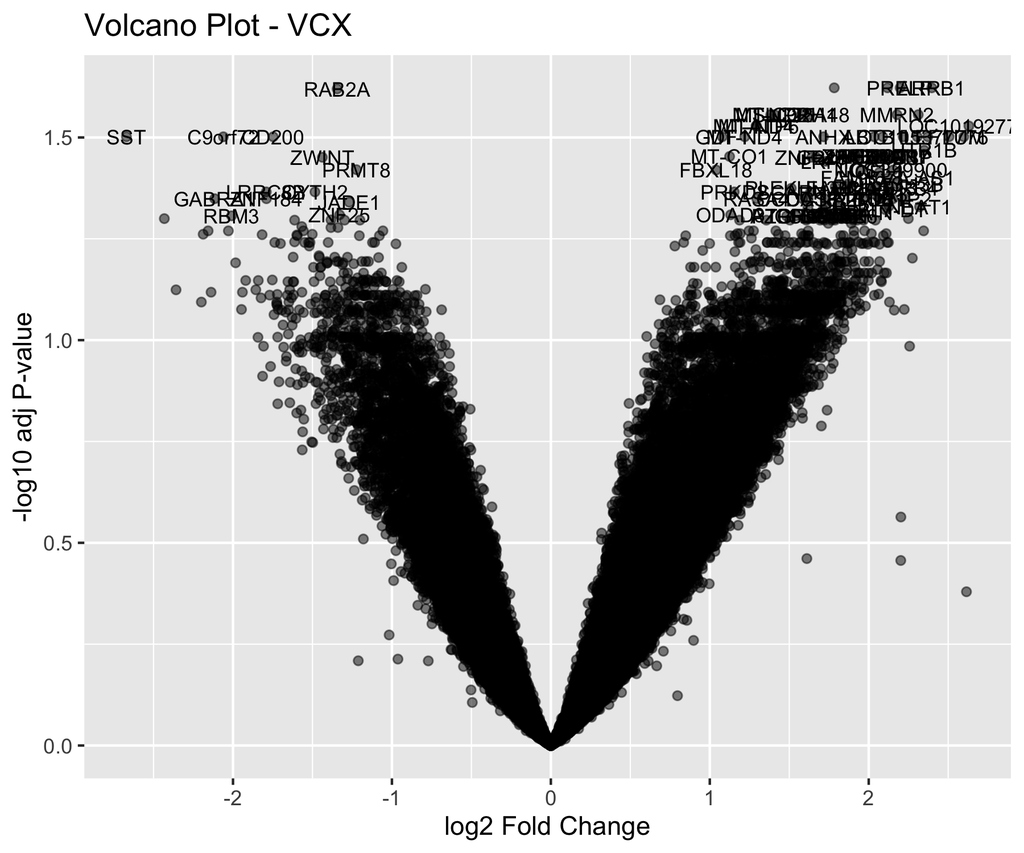

### 5.2. Cross-Region Comparison Plots

top_genes <- lapply(sig_list, function(df) { head(df$SYMBOL, 20) })

all_genes <- unique(unlist(top_genes))

binary_matrix <- sapply(top_genes, function(g) all_genes %in% g)

class(binary_matrix) #check current matrix form

binary_df <- as.data.frame(binary_matrix) #force it to be a datafram

dim(binary_df) #check dimensions

colSums(binary_df)

upset(as.data.frame(binary_matrix), order.by = “freq”) png(“results/plots/cross_region/region_overlap.png”, width = 800, height = 600)

upset(as.data.frame(binary_matrix), order.by = “freq”)

dev.off() #save plot

common_genes <- Reduce(intersect, lapply(sig_list, function(x) x$SYMBOL))

### 5.3. Filtered DE Results per region

sig_list

common_genes <- Reduce(intersect, lapply(sig_list, function(df) df$SYMBOL)) # extract logFC per region #extract logFC per region

logFC_mat <- sapply(names(sig_list), function(region) {

df <- sig_list[[region]]

df$logFC[match(common_genes, df$SYMBOL)]

})

rownames(logFC_mat) <- common_genes #build logFC matrix

logFC_mat <- logFC_mat[rowSums(is.na(logFC_mat)) < ncol(logFC_mat) - 1, ] #clean logFC matrix

pheatmap( logFC_mat, scale = “row”, # very important for interpretation clustering_distance_rows = “correlation”, clustering_distance_cols = “correlation”, clustering_method = “complete”, main = “DE Gene Patterns Across Brain Regions (AD vs Control)” ) #draw heatmap with pheatmap

rowVars(logFC_mat)

top_genes <- names(sort(rowVars(logFC_mat), decreasing = TRUE))[1:50]

logFC_top <- logFC_mat[top_genes, ] #filter to include only top variable genes pheatmap(logFC_top, scale = “row”, na_col = “grey”)

pheatmap(logFC_top, scale = “row”, na_col = “grey”) #draw filtered heatmap dir.create(“results/plots/heatmap”, recursive = TRUE, showWarnings = FALSE) #save heatmap

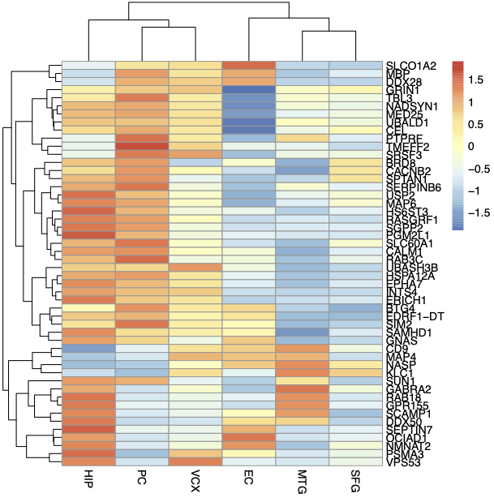

### 5.4. Define AD-relevant genes

alz_genes <- c( “APP”, # amyloid precursor protein “MAPT”, # tau “PSEN1”, “PSEN2”, “APOE”, “BACE1”, “CLU”, “SORL1”, “TREM2”, “NEAT1” # lncRNA involved in neurodegeneration )

alz_genes_present <- intersect(rownames(logFC_mat), alz_genes) #match AD-relevant genes to matrix

notation_df <- data.frame( Alzheimer_gene = ifelse(rownames(logFC_mat) %in% alz_genes_present, “YES”, “NO”) )

rownames(annotation_df) <- rownames(logFC_mat) #create highlited AD version pheatmap( logFC_mat, scale = “row”, na_col = “grey”, annotation_row = annotation_df, clustering_distance_rows = “correlation”, clustering_distance_cols = “correlation”, main = “AD vs Control LogFC (Alzheimer Genes Highlighted)” ) #plot highlighted matrix version

alz_matrix <- logFC_mat[alz_genes_present, , drop = FALSE] #zoom into only AD-relevant genes

pheatmap( alz_matrix, scale = “row”, na_col = “grey”, main = “Alzheimer Disease Core Genes Across Brain Regions” ) #plot heatmap with AD-selected genes

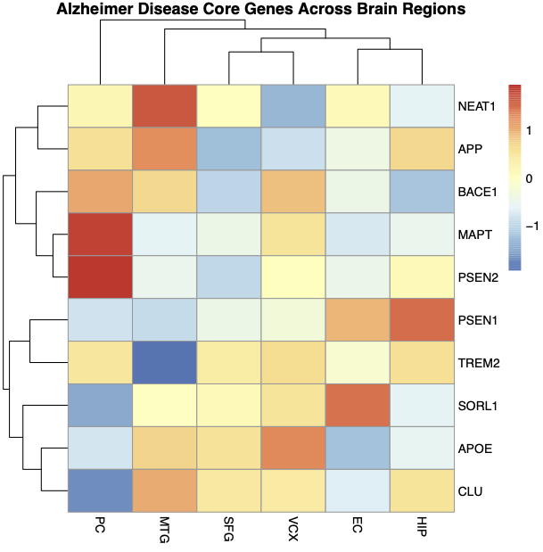